# Examen R

Jorge Cáceres Barrales

2024-07-11

# Objetivo de Investigación

El objetivo de esta investigación es desarrollar y validar funciones en R que permitan la búsqueda eficiente de hiperparámetros utilizando validación cruzada para múltiples algoritmos de aprendizaje automático. Además, se busca implementar una función para la normalización de datos que facilite la preparación de conjuntos de datos para el modelado, asegurando la calidad y consistencia de los mismos.

# Introducción

En el ámbito del aprendizaje automático, la optimización de hiperparámetros y la correcta preparación de los datos son esenciales para mejorar el rendimiento y la precisión de los modelos. En este proyecto, desarrollaremos una función en R que utiliza la librería `caret` para realizar búsquedas de hiperparámetros mediante validación cruzada, aplicada a diferentes algoritmos de aprendizaje automático. Adicionalmente, implementaremos una función de normalización de datos que manejará recodificación de variables categóricas, limpieza de datos y transformación de valores, utilizando principios y paquetes del ecosistema Tidyverse, técnicas de simulación de variables aleatorias, álgebra matricial y algoritmos de optimización.

# Desarrollo

## Carga de Librerías

En este apartado se cargan todas las librerías necesarias para el desarrollo del proyecto, incluyendo librerías para la manipulación de datos, modelado y validación de modelos, así como para la implementación de tests unitarios.

```r
# Cargar librerías necesarias
library(caret)         # Para el preprocesamiento y modelado de datos
library(xgboost)       # Para la implementación del algoritmo de boosting
library(data.table)    # Para la manipulación rápida de datos
library(dplyr)         # Para la manipulación de datos con el uso de pipes
library(stringr)       # Para manipulación de cadenas
library(testthat)      # Para realizar tests unitarios
library(tidyverse)     # Colección de paquetes para manipulación y visualización de datos
```

## Carga de Funciones y Base de Datos

Se cargan funciones específicas desde un archivo alojado en GitHub y se descargan los datos de permisos de circulación en formato CSV también desde GitHub. Esto permite tener acceso a las funciones y datos necesarios para el análisis.

```r
# Enlace raw al archivo de funciones en GitHub
source("https://raw.githubusercontent.com/jkcrs1/R/main/funciones.R")
# Cargar los datos de permisos de circulación desde un CSV en GitHub
url3 <- "https://github.com/jkcrs1/R/raw/main/permiso_circulacion_calbuco.csv"
data_carga <- read.csv(url3, sep = ";", fileEncoding = "ISO-8859-1")
```

## Normalización de las Variables

Se definen las mapeos y listas de columnas necesarias para la normalización de datos, incluyendo columnas categóricas, de fecha, numéricas y el objetivo, así como las columnas requeridas para asegurar la consistencia y limpieza de los datos.

```r
cat_col_mappings <- list(
    tipo_vehiculo = c(
      "AMBULANCIA" = "AMBULANCIA", "AUTOMOVIL" = "AUTOMOVIL",
      "BUS" = "BUS", "Cabriolet" = "AUTOMOVIL", "CAMION" = "CAMION",
      "CAMIONETA" = "CAMIONETA", "CARRO ARRASTRE A" = "REMOLQUE",
      "CARRO BOMBA" = "CARRO BOMBA", "CASA RODANTE" = "CASA RODANTE",
      "Comercial" = "COMERCIAL", "CUATRIMOTO" = "CUATRIMOTO",
      "FURGON" = "FURGON", "GRUA" = "MAQUINA PESADA", "Hatchback" = "AUTOMOVIL",
      "JEEP" = "AUTOMOVIL", "MAQUINA INDUSTRIAL" = "MAQUINA INDUSTRIAL",
      "MINIBUS" = "MINIBUS", "MINIBUS ESCOLAR" = "MINIBUS",
      "MINIBUS PARTICULAR" = "MINIBUS", "MINIBUS PRIVADO" = "MINIBUS",
      "MINIBUS TURISMO" = "MINIBUS", "MOTO" = "MOTOCICLETA",
      "MOTOCICLETA" = "MOTOCICLETA", "OTROS" = "OTROS", "REMOLQUE A" = "REMOLQUE",
      "REMOLQUE B" = "REMOLQUE", "RETROEXCAVADORA" = "MAQUINA PESADA",
      "Sedan" = "AUTOMOVIL", "SEMI REMOLQUE" = "REMOLQUE",
      "STATION WAGON" = "AUTOMOVIL", "SUV" = "SUV", "TAXI EJECUTIVO" = "TAXI",
      "TAXI BASICO" = "TAXI", "TAXI COLECTIVO" = "TAXI", "TRACTOCAMION" = "CAMION",
      "TRACTOR" = "TRACTOR", "VAN" = "VAN"
    ),
    tipo_combustible = c(
      "Benc" = "Bencina", "Dies" = "Diesel", "NULL" = "NULL",
      "DUAL" = "Hibrido", "Hibr" = "Hibrido", "Elec" = "Electrico"
    ),
    transmision = c(
      "Mec" = "Mecanica", "Aut" = "Automatica", "NULL" = "NULL",
      "CVT" = "Automatica", "DCT" = "Automatica"
    )
  )

cat_cols <- c("grupo_vehiculo","tipo_vehiculo", "tipo_combustible",
              "transmision", "marca", "forma_pago")
date_cols <- c("fecha_pago")
numeric_cols <- c("valor_neto", "valor_ipc", "valor_multa", "valor_pagado")
nombre_cols <- c("municipalidad", "grupo_vehiculo", "placa",
                 "digito", "codigo_sii", "forma_pago", "tipo_vehiculo",
                 "marca", "modelo", "color", "transmision",
                 "tipo_combustible", "equipamiento")
target_col <- "valor_pagado"
required_cols <- c("valor_pagado", "fecha_pago")
```

## Funcion para normalizar datos

La función `normalizar_data` se encarga de transformar y limpiar los datos. Realiza la recodificación de variables categóricas, reemplaza valores nulos, convierte datos numéricos y de fecha, y filtra duplicados. Al final, retorna los datos normalizados junto con la duración del proceso en formato S3.

```r
normalizar_data <- function(data,
                            cat_col_mappings = list(),
                            cat_cols = c(),
                            date_cols = c(),
                            numeric_cols = c(),
                            title_cols = c(),
                            target_col = NULL,
                            required_cols = c(),
                            date_format = "%d-%m-%y",
                            replace_nas = TRUE,
                            replace_nas_with_median = TRUE) {

  # Marcar el inicio del tiempo de ejecución
  hora_inicio <- Sys.time()

  cat("La cantidad de registros:", nrow(data), "\n")

  # Convertir data a data.frame (por si no lo es)
  data <- data.frame(data)

  # Cambio de nombres de columnas: reemplazar puntos por guiones bajos y convertir a minúsculas
  colnames(data) <- colnames(data) %>% str_replace_all("\\.", "_") %>% tolower()

  # Recodificar las variables categóricas según los mapeos proporcionados
  for (col in names(cat_col_mappings)) {
    if (col %in% colnames(data) && !is.null(data[[col]])) {
      data[[col]] <- dplyr::recode(data[[col]], !!!cat_col_mappings[[col]])
      # dplyr::recode para recodificar
    }
  }

  # Reemplazar nulos en todas las variables numéricas si replace_nas es TRUE
  if (replace_nas) {
    data <- data %>%
      dplyr::mutate(dplyr::across(where(is.numeric),
                                  ~ replace_na(., median(., na.rm = TRUE))))
    # dplyr::mutate y dplyr::across para transformación
  }

  # Convertir a título en variables específicas
  if (length(title_cols) > 0) {
    data <- data %>%
      dplyr::mutate(dplyr::across(all_of(title_cols), stringr::str_to_title))
    # dplyr::mutate y stringr::str_to_title para conversión a título
  }

  # Quitar las "," y "." de los campos de valores y convertir a numérico
  if (length(numeric_cols) > 0) {
    data <- data %>%
      dplyr::mutate(dplyr::across(all_of(numeric_cols),
                                  ~ as.numeric(gsub("[,\\.]", "", .))))
    # dplyr::mutate y gsub para limpieza y conversión
  }

  # Convertir columnas de fecha
  if (length(date_cols) > 0) {
    for (col in date_cols) {
      if (col %in% colnames(data) && !is.null(data[[col]])) {
        data[[col]] <- as.Date(data[[col]], format = date_format)
        # base::as.Date para conversión de fechas
      }
    }

    # Crear nuevas variables basadas en fechas
    if (date_cols[1] %in% colnames(data)) {
      data <- data %>%
        dplyr::mutate(
          ano_pago = lubridate::year(data[[date_cols[1]]]),
          # lubridate::year para extraer año
          mes_pago = lubridate::month(data[[date_cols[1]]]),
          # lubridate::month para extraer mes
          ano_mes_pago = paste(sprintf("%02d", mes_pago),
                               substr(ano_pago, 3, 4), sep = "-")
          # base::paste y base::sprintf para formateo
        )
    }
  }

  # Filtrar y eliminar duplicados específicos
  for (col in required_cols) {
    if (col %in% colnames(data)) {
      data <- data %>%
        dplyr::filter(!is.na(data[[col]]) & data[[col]] > 0) %>%
        dplyr::distinct()
      # dplyr::filter y dplyr::distinct para filtrar y eliminar duplicados
    }
  }

  # Filtrar y eliminar duplicados si la columna objetivo está definida
  if (!is.null(target_col) && target_col %in% colnames(data)) {
    data <- data %>%
      dplyr::filter(!is.na(data[[target_col]]) & data[[target_col]] > 0) %>%
      dplyr::distinct()
  }

  # Transformación de variables categóricas a factores, manteniendo las columnas originales
  if (length(cat_cols) > 0) {
    for (col in cat_cols) {
      if (col %in% colnames(data)) {
        data[[paste0(col, "_factor")]] <- as.numeric(as.factor(data[[col]]))
        # base::as.numeric y base::as.factor para conversión
      }
    }
  }

  # Incluye la transformación adicional de variables categóricas a factores
  data <- data %>%
    dplyr::mutate(dplyr::across(where(is.character), as.factor),
                  fecha = as.Date(paste(ano_pago, mes_pago, "01", sep = "-"),
                                  format = "%Y-%m-%d"),
                  ano_mes_pago = paste(sprintf("%02d", mes_pago),
                                       substr(ano_pago, 3, 4), sep = "-")) %>%
    dplyr::arrange(fecha) %>%
    dplyr::mutate(ano_mes_pago = factor(ano_mes_pago,
                                        levels = unique(ano_mes_pago))) %>%
    dplyr::select(-fecha)

  # Reemplazar valores nulos por la mediana en todas las variables si replace_nas_with_median es TRUE
  if (replace_nas_with_median) {
    data <- data %>%
      dplyr::mutate(dplyr::across(where(is.numeric), ~
                                    replace_na(., median(., na.rm = TRUE))))
  }

  # Droplevels para la variable marca (si existe)
  if ("marca" %in% colnames(data)) {
    data$marca <- factor(data$marca)
    data$marca <- droplevels(data$marca)
  }

  # Convertir variables categóricas a numéricas, manteniendo las columnas originales
  data <- data %>%
    dplyr::mutate(dplyr::across(ends_with("_factor"), as.numeric))

  # Mostrar la cantidad de registros válidos
  cat("La cantidad de registros válidos:", nrow(data), "\n")

  # Marcar el fin del tiempo de ejecución y calcular la duración
  hora_fin <- Sys.time()
  duracion <- difftime(hora_fin, hora_inicio, units = "secs")
  duracion_formateada <- sprintf("%02d:%02d:%02d",
                                 as.integer(duracion) %/% 3600,
                                 (as.integer(duracion) %% 3600) %/% 60,
                                 as.integer(duracion) %% 60)

  # Mostrar el tiempo de ejecución
  cat("Tiempo de ejecución:", duracion_formateada, "segundos\n")

  resultado <- list(data = data, duracion = duracion_formateada)
  class(resultado) <- "normalizacion_resultado"
  return(resultado)
}

# Método para imprimir la clase S3
print.normalizacion_resultado <- function(x) {
  cat("Datos normalizados:\n")
  print(head(x$data))
  cat("\nDuración de la normalización:", x$duracion, "\n")
}
```

## Normalizar Dataset

Se aplica la función `normalizar_data` al conjunto de datos cargado previamente, utilizando las configuraciones de mapeo y columnas definidas. Esto normaliza y limpia los datos para su posterior análisis.

```r
# Aplicar la función al dataset
resultado_normalizacion <- normalizar_data(data_carga,
                                           cat_col_mappings,
                                           cat_cols,
                                           date_cols,
                                           numeric_cols,
                                           nombre_cols,
                                           target_col)
```

```
## La cantidad de registros: 63886
## La cantidad de registros válidos: 63819
## Tiempo de ejecución: 00:00:02 segundos
```

## Preparacion Dataset

Se realiza un balanceo del dataset utilizando muestreo estratificado para asegurar una distribución equitativa de los tipos de vehículos. Esto es importante para evitar sesgos en el modelo de aprendizaje automático.

```r
# Extraer el data frame normalizado
data <- resultado_normalizacion$data

# Filtrar los datos para incluir solo automóviles y camionetas
data <- data %>% dplyr::filter(tipo_vehiculo == "Automovil" | tipo_vehiculo == "Camioneta")

# Continuar con la preparación del dataset
data <- data %>%
  dplyr::select(grupo_vehiculo, grupo_vehiculo_factor,
                ano_vehiculo, tipo_de_pago, fecha_pago,
                ano_pago, mes_pago, ano_mes_pago,
                valor_neto, valor_ipc, valor_multa,
                valor_pagado, forma_pago, forma_pago_factor,
                tipo_vehiculo, tipo_vehiculo_factor,
                marca, marca_factor)
```

## Outliers

Se aplica la función `eliminar_outliers` para eliminar valores atípicos en la columna `valor_pagado` del dataset.

```r
resultado <- eliminar_outliers(data, "valor_pagado")

dataset_sin_outliers <- resultado$dataset_sin_outliers

cat("Número de registros originales:", nrow(data), "\n")
```

```
## Número de registros originales: 54231
```

```r
cat("Número de registros sin outliers:", nrow(dataset_sin_outliers), "\n")
```

```
## Número de registros sin outliers: 49079
```

```r
data<- dataset_sin_outliers
```

## Balanceo de datos

Se realiza un balanceo de datos para evitar el sobreajuste en el modelo.

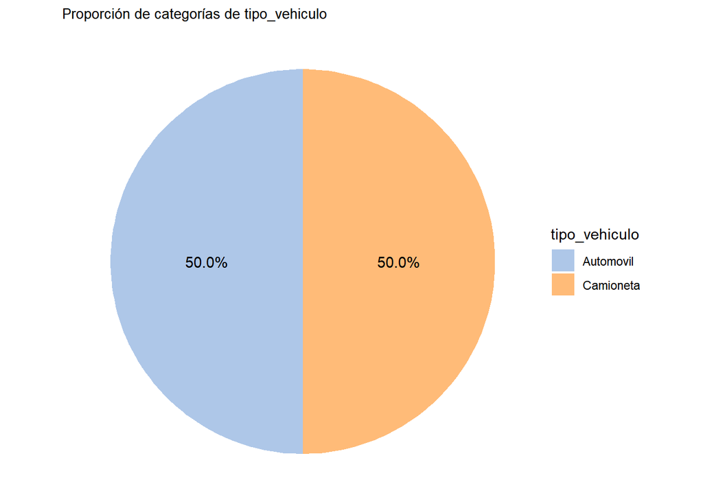

```r
set.seed(123)
tamano_muestra <- min(data %>% count(tipo_vehiculo) %>% pull(n))

# Muestreo estratificado para asegurar la misma cantidad de datos por categoría
data <- data %>%
  dplyr::group_by(tipo_vehiculo) %>%
  dplyr::sample_n(tamano_muestra) %>%
  dplyr::ungroup()

# Visualización de la distribución del tipo de vehículo
grafico_torta(data, "tipo_vehiculo")
```

## Variable Objetivo

Se usa la función `grafico_boxplot` para representar gráficamente la distribución de `valor_pagado`, incluyendo la mediana, los cuartiles, y los valores máximos y mínimos, permitiendo una comprensión clara de la dispersión y centralización de los datos.

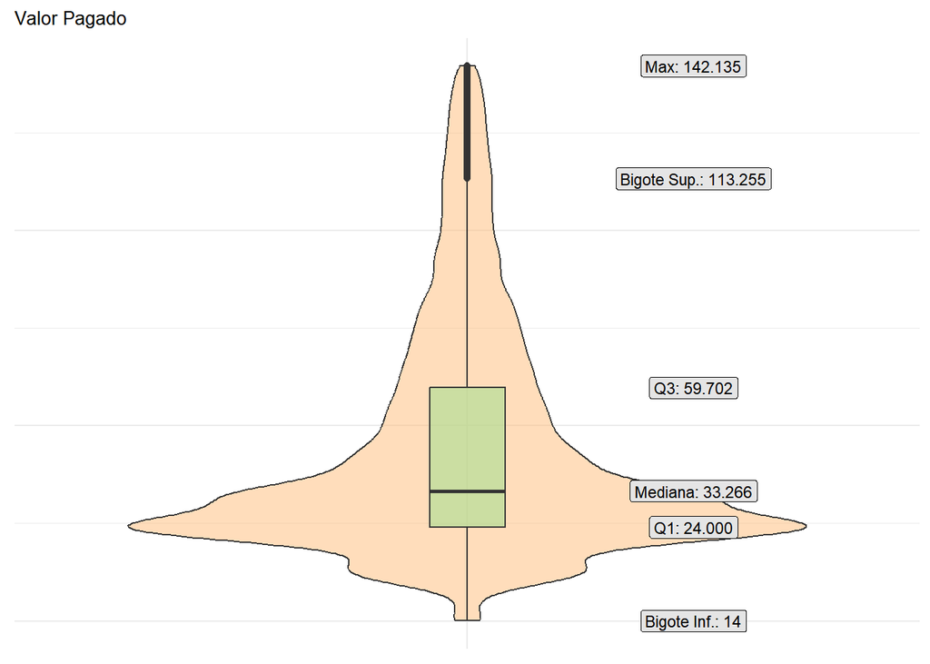

```r
grafico_boxplot(data, "valor_pagado","Valor Pagado")
```

## Funcion de Búsqueda de Hiperparametro

La función `GridSearchCV_xgboost` realiza una búsqueda de hiperparámetros utilizando validación cruzada para el algoritmo XGBoost. Calcula dinámicamente el número de folds, evalúa múltiples combinaciones de hiperparámetros y retorna los mejores parámetros encontrados junto con la duración del proceso. La función utiliza una estructura S3 para manejar los resultados de manera flexible y estructurada.

```r
GridSearchCV_xgboost <- function(parameters, scoring, data, target) {

  # Marcar el inicio del tiempo de ejecución
  hora_inicio <- Sys.time()

  # Calcular el número de folds basado en el tamaño del dataset
  n_folds <- min(10, max(2, nrow(data) %/% 100))

  # Crear el grid de hiperparámetros
  grid <- expand.grid(parameters)
  results <- list()

  # Preparar los datos para xgboost
  dtrain <- xgb.DMatrix(data = as.matrix(data %>% select(-all_of(target))),
                        label = data[[target]])

  # Realizar cross-validation para cada combinación de hiperparámetros
  for (i in 1:nrow(grid)) {
    params <- grid[i, ]
    param_list <- as.list(params)
    nrounds <- param_list$nrounds
    param_list$nrounds <- NULL

    cv <- xgb.cv(params = param_list,
                 data = dtrain,
                 nfold = n_folds,
                 nrounds = nrounds,
                 metrics = list(scoring),
                 verbose = FALSE,
                 early_stopping_rounds = 10,
                 maximize = ifelse(scoring == "rmse", FALSE, TRUE))

    # Ajustar el nombre de la métrica para coincidir con la salida de xgb.cv
    metric_name <- paste("test", scoring, "mean", sep = "_")
    if (!is.null(cv$evaluation_log[[metric_name]])) {
      best_score <- min(cv$evaluation_log[[metric_name]])
      results[[i]] <- list(params = param_list, score = best_score)
    } else {
      warning(paste("Métrica no encontrada:", metric_name))
    }
  }

  # Encontrar la mejor combinación de hiperparámetros
  if (length(results) > 0) {
    best_result <- results[[which.min(sapply(results, function(x) x$score))]]
  } else {
    stop("No se encontraron resultados válidos durante la validación cruzada.")
  }

  hora_fin <- Sys.time()
  duracion <- difftime(hora_fin, hora_inicio, units = "secs")
  duracion_formateada <- sprintf("%02d:%02d:%02d",
                                 as.integer(duracion) %/% 3600,
                                 (as.integer(duracion) %% 3600) %/% 60,
                                 as.integer(duracion) %% 60)

  # Crear la lista de resultados con clase S3
  resultado <- list(best_result = best_result, duracion = duracion_formateada)
  class(resultado) <- "grid_search_result"
  return(resultado)
}

# Método para imprimir la clase S3
print.grid_search_result <- function(x) {
  cat("Mejores hiperparámetros:\n")
  print(x$best_result$params)
  cat("\nPuntuación:\n")
  print(x$best_result$score)
  cat("\nDuración de la búsqueda de hiperparámetros:", x$duracion, "\n")
}
```

## Aplicación de la Función

Se define un grid de hiperparámetros para XGBoost y se preparan los datos. Luego, se aplica la función `GridSearchCV_xgboost` para encontrar los mejores hiperparámetros y se imprimen los resultados, incluyendo los parámetros óptimos y la puntuación del modelo.

```r
# Definir los hiperparámetros a tunear para xgboost
parameters <- list(
  nrounds = c(50, 100),
  max_depth = c(3, 6),
  eta = c(0.1, 0.3),
  gamma = c(0, 1),
  colsample_bytree = c(0.5, 0.7),
  min_child_weight = c(1, 3),
  subsample = c(0.6, 0.8)
)

# Preparar los datos para xgboost
data_xgb <- data %>%
  dplyr::mutate(dplyr::across(where(is.factor), as.numeric)) %>%
  dplyr::select(-tipo_vehiculo, -fecha_pago)

# Aplicar la búsqueda de hiperparámetros con xgboost
best_model <- GridSearchCV_xgboost(
  parameters = parameters,
  scoring = "rmse",
  data = data_xgb,
  target = "valor_pagado"
)

# Mostrar los mejores hiperparámetros y la puntuación correspondiente
print(best_model)
```

```
## Mejores hiperparámetros:
## $max_depth
## [1] 6
##
## $eta
## [1] 0.1
##
## $gamma
## [1] 0
##
## $colsample_bytree
## [1] 0.7
##
## $min_child_weight
## [1] 1
##
## $subsample
## [1] 0.8
##
## attr(,"out.attrs")
## attr(,"out.attrs")$dim
##          nrounds        max_depth              eta            gamma
##                2                2                2                2
## colsample_bytree min_child_weight        subsample
##                2                2                2
##
## attr(,"out.attrs")$dimnames
## attr(,"out.attrs")$dimnames$nrounds
## [1] "nrounds= 50" "nrounds=100"
##
## attr(,"out.attrs")$dimnames$max_depth
## [1] "max_depth=3" "max_depth=6"
##
## attr(,"out.attrs")$dimnames$eta
## [1] "eta=0.1" "eta=0.3"
##
## attr(,"out.attrs")$dimnames$gamma
## [1] "gamma=0" "gamma=1"
##
## attr(,"out.attrs")$dimnames$colsample_bytree
## [1] "colsample_bytree=0.5" "colsample_bytree=0.7"
##
## attr(,"out.attrs")$dimnames$min_child_weight
## [1] "min_child_weight=1" "min_child_weight=3"
##
## attr(,"out.attrs")$dimnames$subsample
## [1] "subsample=0.6" "subsample=0.8"
##
##
##
## Puntuación:
## [1] 2603.711
##
## Duración de la búsqueda de hiperparámetros: 00:18:01
```

## Interpretacion del Resultado de la funcion

**Mejores Hiperparámetros Determinados**:

- **max_depth**: El valor óptimo encontrado fue 6, indicando que cada árbol en el modelo tiene una profundidad máxima de 6 niveles. Este nivel de profundidad permite al modelo capturar suficiente complejidad en los datos sin sobreajustarse.
- **eta**: La tasa de aprendizaje óptima fue 0.1. Este parámetro controla la magnitud de la actualización en cada ronda de boosting, y un valor de 0.1 sugiere que el modelo realiza actualizaciones más pequeñas, lo que generalmente conduce a una mejor generalización.
- **gamma**: El valor de gamma fue 0, lo que significa que no se requiere una ganancia mínima para realizar una partición adicional en un nodo de un árbol. Esto permite una mayor flexibilidad en la construcción del árbol.
- **colsample_bytree**: La proporción de columnas usadas por árbol fue 0.7, lo que implica que el 70% de las características se utilizan para construir cada árbol. Esto introduce diversidad en los árboles y mejora la generalización del modelo.
- **min_child_weight**: Este parámetro se optimizó a 1, lo que significa que un nodo se dividirá solo si su suma de pesos es al menos 1. Este parámetro ayuda a controlar la complejidad del modelo y evitar el sobreajuste.
- **subsample**: La proporción de muestra fue 0.8, lo que significa que el 80% de los datos de entrenamiento se utilizan para construir cada árbol. Esto introduce aleatoriedad y mejora la capacidad del modelo para generalizar.

# Testing de funcion usando testthat

## Test de GridSearchCV

```r
# Prueba de la función GridSearchCV

test_that("GridSearchCV_xgboost funciona correctamente", {

  # Cargar datos de prueba
  data_url <- "https://github.com/jkcrs1/R/raw/main/permiso_circulacion_calbuco.csv"
  data_test <- data.table::fread(data_url, sep = ";", encoding = "Latin-1")

  cat_col_mappings <- list(
    tipo_vehiculo = c(
      "AMBULANCIA" = "AMBULANCIA", "AUTOMOVIL" = "AUTOMOVIL",
      "BUS" = "BUS", "Cabriolet" = "AUTOMOVIL", "CAMION" = "CAMION",
      "CAMIONETA" = "CAMIONETA", "CARRO ARRASTRE A" = "REMOLQUE",
      "CARRO BOMBA" = "CARRO BOMBA", "CASA RODANTE" = "CASA RODANTE",
      "Comercial" = "COMERCIAL", "CUATRIMOTO" = "CUATRIMOTO",
      "FURGON" = "FURGON", "GRUA" = "MAQUINA PESADA", "Hatchback" = "AUTOMOVIL",
      "JEEP" = "AUTOMOVIL", "MAQUINA INDUSTRIAL" = "MAQUINA INDUSTRIAL",
      "MINIBUS" = "MINIBUS", "MINIBUS ESCOLAR" = "MINIBUS",
      "MINIBUS PARTICULAR" = "MINIBUS", "MINIBUS PRIVADO" = "MINIBUS",
      "MINIBUS TURISMO" = "MINIBUS", "MOTO" = "MOTOCICLETA",
      "MOTOCICLETA" = "MOTOCICLETA", "OTROS" = "OTROS", "REMOLQUE A" = "REMOLQUE",
      "REMOLQUE B" = "REMOLQUE", "RETROEXCAVADORA" = "MAQUINA PESADA",
      "Sedan" = "AUTOMOVIL", "SEMI REMOLQUE" = "REMOLQUE",
      "STATION WAGON" = "AUTOMOVIL", "SUV" = "SUV", "TAXI EJECUTIVO" = "TAXI",
      "TAXI BASICO" = "TAXI", "TAXI COLECTIVO" = "TAXI", "TRACTOCAMION" = "CAMION",
      "TRACTOR" = "TRACTOR", "VAN" = "VAN"
    ),
    tipo_combustible = c(
      "Benc" = "Bencina", "Dies" = "Diesel", "NULL" = "NULL",
      "DUAL" = "Hibrido", "Hibr" = "Hibrido", "Elec" = "Electrico"
    ),
    transmision = c(
      "Mec" = "Mecanica", "Aut" = "Automatica", "NULL" = "NULL",
      "CVT" = "Automatica", "DCT" = "Automatica"
    )
  )

  cat_cols <- c("tipo_vehiculo", "tipo_combustible", "transmision", "marca")
  date_cols <- c("fecha_pago")
  numeric_cols <- c("valor_neto", "valor_ipc", "valor_multa", "valor_pagado")
  nombre_cols <- c("municipalidad", "grupo_vehiculo", "placa",
                   "digito", "codigo_sii", "forma_pago", "tipo_vehiculo",
                   "marca", "modelo", "color", "transmision",
                   "tipo_combustible", "equipamiento")
  target_col <- "valor_pagado"
  required_cols <- c("valor_pagado", "fecha_pago")

  # Normalizar y transformar el dataset
  data_test <- normalizar_data(data_test,
                               cat_col_mappings,
                               cat_cols,
                               date_cols,
                               numeric_cols,
                               nombre_cols,
                               target_col,
                               required_cols)

  data_test <- data_test$data %>%
    dplyr::mutate(dplyr::across(where(is.factor), as.numeric)) %>%
    dplyr::select(-tipo_vehiculo, -fecha_pago)

  parameters <- list(
    nrounds = c(50, 100),
    max_depth = c(3, 6),
    eta = c(0.1, 0.3),
    gamma = c(0, 1),
    colsample_bytree = c(0.5, 0.7),
    min_child_weight = c(1, 3),
    subsample = c(0.6, 0.8)
  )

  # Capturar la salida de la función GridSearchCV_xgboost
  result <- GridSearchCV_xgboost(parameters, "rmse", data_test, "valor_pagado")
  salida <- capture.output({
    print(result)
    cat("Tiempo de ejecución:", result$duracion, "segundos\n")
  })

  # Verificar que las transformaciones se realizaron correctamente
  expect_s3_class(result, "grid_search_result")
  expect_true("params" %in% names(result$best_result))
  expect_true("score" %in% names(result$best_result))
  expect_match(paste(salida, collapse = "\n"), "Tiempo de ejecución:")
})
```

```
## La cantidad de registros: 63886
## La cantidad de registros válidos: 56566
## Tiempo de ejecución: 00:00:02 segundos
## Test passed 😀
```

## Test de normalizar_data

Se realiza una prueba de la función `normalizar_data` utilizando `testthat`. Se carga un conjunto de datos de prueba y se aplica la función de normalización. La prueba verifica que las transformaciones y los resultados se han realizado correctamente, incluyendo la validación de las columnas y la duración del proceso.

```r
test_that("normalizar_data funciona correctamente con datos reales", {
  data_url <- "https://github.com/jkcrs1/R/raw/main/permiso_circulacion_calbuco.csv"
  data_test <- data.table::fread(data_url, sep = ";", encoding = "Latin-1")

  cat_col_mappings <- list(
    tipo_vehiculo = c(
      "AMBULANCIA" = "AMBULANCIA", "AUTOMOVIL" = "AUTOMOVIL", "BUS" = "BUS",
      "Cabriolet" = "AUTOMOVIL", "CAMION" = "CAMION", "CAMIONETA" = "CAMIONETA",
      "CARRO ARRASTRE A" = "REMOLQUE", "CARRO BOMBA" = "CARRO BOMBA",
      "CASA RODANTE" = "CASA RODANTE", "Comercial" = "COMERCIAL", "CUATRIMOTO" = "CUATRIMOTO",
      "FURGON" = "FURGON", "GRUA" = "MAQUINA PESADA", "Hatchback" = "AUTOMOVIL",
      "JEEP" = "AUTOMOVIL", "MAQUINA INDUSTRIAL" = "MAQUINA INDUSTRIAL",
      "MINIBUS" = "MINIBUS", "MINIBUS ESCOLAR" = "MINIBUS", "MINIBUS PARTICULAR" = "MINIBUS",
      "MINIBUS PRIVADO" = "MINIBUS", "MINIBUS TURISMO" = "MINIBUS", "MOTO" = "MOTOCICLETA",
      "MOTOCICLETA" = "MOTOCICLETA", "OTROS" = "OTROS", "REMOLQUE A" = "REMOLQUE",
      "REMOLQUE B" = "REMOLQUE", "RETROEXCAVADORA" = "MAQUINA PESADA", "Sedan" = "AUTOMOVIL",
      "SEMI REMOLQUE" = "REMOLQUE", "STATION WAGON" = "AUTOMOVIL", "SUV" = "SUV",
      "TAXI EJECUTIVO" = "TAXI", "TAXI BASICO" = "TAXI", "TAXI COLECTIVO" = "TAXI",
      "TRACTOCAMION" = "CAMION", "TRACTOR" = "TRACTOR", "VAN" = "VAN"
    ),
    tipo_combustible = c(
      "Benc" = "Bencina", "Dies" = "Diesel", "NULL" = "NULL",
      "DUAL" = "Hibrido", "Hibr" = "Hibrido", "Elec" = "Electrico"
    ),
    transmision = c(
      "Mec" = "Mecanica", "Aut" = "Automatica", "NULL" = "NULL",
      "CVT" = "Automatica", "DCT" = "Automatica"
    )
  )

  cat_cols <- c("tipo_vehiculo", "tipo_combustible", "transmision", "marca")
  date_cols <- c("fecha_pago")
  numeric_cols <- c("valor_neto", "valor_ipc", "valor_multa", "valor_pagado")
  title_cols <- c("municipalidad", "grupo_vehiculo", "placa", "digito", "codigo_sii", "forma_pago", "tipo_vehiculo", "marca", "modelo", "color", "transmision", "tipo_combustible", "equipamiento")
  target_col <- "valor_pagado"
  required_cols <- c("valor_pagado", "fecha_pago")

  # Capturar la salida de la función normalizar_data
  salida <- capture.output({
    resultado <- normalizar_data(data_test,
                                 cat_col_mappings,
                                 cat_cols,
                                 date_cols,
                                 numeric_cols,
                                 title_cols,
                                 target_col,
                                 required_cols)
  })

  data_normalizada <- resultado$data

  # Verificar que las transformaciones se realizaron correctamente
  for (col in cat_cols) {
    expect_true(paste0(col, "_factor") %in% colnames(data_normalizada))
  }

  expect_true(all(!is.na(data_normalizada$valor_pagado)))
  expect_true(all(!is.na(data_normalizada$fecha_pago)))

  # Verificar que las columnas originales aún existen
  for (col in cat_cols) {
    expect_true(col %in% colnames(data_normalizada))
  }

  # Verificar que el tiempo de ejecución se muestra en la salida
  expect_match(paste(salida, collapse = "\n"), "Tiempo de ejecución:")
})
```

```
## Test passed 🎉
```

# Conclusión

En este proyecto, desarrollamos y validamos funciones en R para la normalización de datos y la búsqueda de hiperparámetros, enfocándonos en mejorar la eficiencia de los algoritmos de aprendizaje automático.

*Función de Normalización*: La función `normalizar_data` transforma y limpia los conjuntos de datos, recodificando variables categóricas, normalizando valores y eliminando duplicados. La salida se estructuró como un objeto S3 para mayor flexibilidad. La función se validó exitosamente con datos reales, demostrando su robustez y precisión.

*Búsqueda de Hiperparámetros*: Implementamos `GridSearchCV_xgboost`, que realiza la búsqueda de hiperparámetros utilizando validación cruzada para XGBoost. La función calcula dinámicamente los folds y devuelve los mejores hiperparámetros. El diseño S3 de la función facilita su extensibilidad y manejo intuitivo de resultados.

*Pruebas y Validación*: Utilizamos `testthat` para validar las funciones, asegurando que las transformaciones y resultados de la búsqueda de hiperparámetros fueran correctos. Las pruebas incluyeron medidas de tiempo de ejecución, proporcionando información sobre la eficiencia de las funciones.

Este trabajo establece una base sólida para futuros proyectos en data science, demostrando buenas prácticas en la estructuración y documentación de proyectos en R, y ofrece herramientas robustas para la normalización de datos y optimización de modelos.